# Database harmonisation by scpeaker - Part 1

Database harmonisation between CellChatDB.human(v2.2.0) and CellPhoneDB (V5.0.1)

Author

Ho Jin Ker Nigel, Adaikalavan Ramasamy, Gokce Oguz

Published

December 30, 2025

# Introduction

In this document, we outline the database harmonisation steps taken to determine the degree of overlap between CellChat and CellPhoneDB, which are listed as:

- Step 1: Converting gene symbols to Uniprot ID format in CellChatDB
- Step 2: Identifying duplicates, missing or invalid entries in CellChatDB and CellPhoneDB
- Step 3: Convert complexes in CellPhoneDB to Uniprot ID format
- Step 4: Sorting protein subunits of complexes in both databases
- Step 5: Swapping ligand-receptor pairs to identify missed overlaps
- Step 6: Partial mapping of complexes

Additionally, we describe the process to customize CellChatDB and CellPhoneDB with the revised changes implemented.

# Load required packages and download CellChatDB and CellPhoneDB databases

## Load required packages

```r
pacman::p_load(tidyverse, janitor, CellChat)
setwd(this.path::here())
rm(list = ls())

# File creation
if (! dir.exists("../data/db_utils")) sapply("../data/db_utils", dir.create, recursive = TRUE)

# Function for summarizing overlap between databases
join_summarize <- function(db1, db2){

  db1$LR <- paste0( db1$ligand, "|", db1$receptor )
  db2$LR <- paste0( db2$ligand, "|", db2$receptor )

  comb <- inner_join(db1, db2, by = "LR", suffix = c("_db1", "_db2"))

  cat(" # ligand-receptors =", comb %>% distinct(LR) %>% nrow(), "\n",
      "# simple ligands    =", comb %>% filter(!complex_ligand_db1)   %>% distinct(ligand_db1)   %>% nrow(), "\n",
      "# simple receptors  =", comb %>% filter(!complex_receptor_db1) %>% distinct(receptor_db1) %>% nrow(), "\n",
      "# complex ligands   =", comb %>% filter(complex_ligand_db1)    %>% distinct(ligand_db1)   %>% nrow(), "\n",
      "# complex receptors =", comb %>% filter(complex_receptor_db1)  %>% distinct(receptor_db1) %>% nrow(), "\n"
  )

  return(comb %>% distinct(LR, .keep_all = TRUE))
}
```

NOTE: `join_summarize()` returns a summary table that includes the number of overlapping interactions across two databases, which we define as a match of the ligand|receptor pair, the number of simple ligands and receptors made up of a single gene, as well as the number of overlapping complexes made up of more than one gene. From CellChat (v2) and CellPhoneDB (v5) onward, both packages included **non-protein signaling** interactions in their latest databases. As such, interactions involving non-protein signaling may contain only one gene, should the hormone/molecule be produced by only one enzyme in its biosynthesis.

# STEP 1: Map Gene Symbol to UniProt in CellChatDB

CellChatDB.human (CCDB) defines ligands and receptors using gene symbols, whereas CellPhoneDB (CPDB) defines them using UniProt IDs. To harmonize the two databases, we used the `geneInfo` slot to map CCDB gene symbols to their corresponding UniProt IDs. For example, the gene symbol EGF was converted to P01133.

CellChat version 2.2.0.9001 stores the database within R under `CellChatDB.human`.

```r
pacman::p_version("CellChat")
```

```
[1] '2.2.0.9001'
```

## Prepare CCDB gene-to-uniprot conversion

```r
# Gene symbol to UniProt mapping
map <- CellChatDB.human$geneInfo %>%
  select(Symbol, EntryID.uniprot) %>%
  drop_na() %>%
  deframe()

map %>% length()
```

```
[1] 26823
```

```r
map %>% head()
```

```
    A1BG     A1CF      A2M    A2ML1  A3GALT2   A4GALT
"P04217" "Q9NQ94" "P01023" "A8K2U0" "U3KPV4" "Q9NPC4"
```

### Map complex to UniProt complexes and concatenate

CCDB contains complex interaction partners composed of multiple protien subunits. We convert the gene symbols of these proteins to Uniprot ID format.

```r
complex <- CellChatDB.human$complex %>%
  mutate(complex_name = rownames(.))

complex %>% dim()
```

```
[1] 338   6
```

```r
complex %>% head()
```

```
             subunit_1 subunit_2 subunit_3 subunit_4 subunit_5 complex_name
Activin AB       INHBA     INHBB                                 Activin AB
Inhibin A         INHA     INHBA                                  Inhibin A
Inhibin B         INHA     INHBB                                  Inhibin B
IL12AB           IL12A     IL12B                                     IL12AB
IL23 complex     IL12B     IL23A                               IL23 complex
IL27 complex      IL27      EBI3                               IL27 complex
```

```r
example <- c("12oxoLTB4-PTGR1", "TREM2_TYROBP", "RARA_RXRA_CRABP2",
             "Pregnenolone-CYP11A1", "HTR3_complex")
```

Before converting the gene symbols to Uniprot ID format, `complex` looks like:

|  | subunit_1 | subunit_2 | subunit_3 | subunit_4 | subunit_5 | complex_name |
| --- | --- | --- | --- | --- | --- | --- |
| 12oxoLTB4-PTGR1 | PTGR1 |  |  |  |  | 12oxoLTB4-PTGR1 |
| TREM2_TYROBP | TREM2 | TYROBP |  |  |  | TREM2_TYROBP |
| RARA_RXRA_CRABP2 | RARA | RXRA | CRABP2 |  |  | RARA_RXRA_CRABP2 |
| Pregnenolone-CYP11A1 | CYP11A1 | FDX2 | FDX1 | FDXR |  | Pregnenolone-CYP11A1 |
| HTR3_complex | HTR3A | HTR3B | HTR3C | HTR3D | HTR3E | HTR3_complex |

```r
# Perfrom gene-to-uniprot conversion
complex$subunit_1 <- map[complex$subunit_1]
complex$subunit_2 <- map[complex$subunit_2]
complex$subunit_3 <- map[complex$subunit_3]
complex$subunit_4 <- map[complex$subunit_4]
complex$subunit_5 <- map[complex$subunit_5]
```

After converting the gene symbols to Uniprot ID format, `complex` now looks like:

|  | subunit_1 | subunit_2 | subunit_3 | subunit_4 | subunit_5 | complex_name |
| --- | --- | --- | --- | --- | --- | --- |
| 12oxoLTB4-PTGR1 | Q14914 | NA | NA | NA | NA | 12oxoLTB4-PTGR1 |
| TREM2_TYROBP | Q9NZC2 | O43914 | NA | NA | NA | TREM2_TYROBP |
| RARA_RXRA_CRABP2 | P10276 | P19793 | P29373 | NA | NA | RARA_RXRA_CRABP2 |
| Pregnenolone-CYP11A1 | P05108 | Q6P4F2 | P10109 | P22570 | NA | Pregnenolone-CYP11A1 |
| HTR3_complex | P46098 | O95264 | Q8WXA8 | Q70Z44 | A5X5Y0 | HTR3_complex |

We concatenate the Uniprot IDs of the protein subunits for each complex to form a single character value which represents it.

```r
complex <- complex %>% select(-complex_name) # remove unused "complex_name" column

complex <- apply(complex, 1, function(x) paste(na.omit(x), collapse = "_"))

complex[which(names(complex) %in% example)]
```

```
                     12oxoLTB4-PTGR1                         TREM2_TYROBP
                            "Q14914"                      "Q9NZC2_O43914"
                    RARA_RXRA_CRABP2                 Pregnenolone-CYP11A1
              "P10276_P19793_P29373"        "P05108_Q6P4F2_P10109_P22570"
                        HTR3_complex
"P46098_O95264_Q8WXA8_Q70Z44_A5X5Y0"
```

### Convert all interaction partners in CCDB to their respective Uniprot ID format

CCDB stores all 3233 interactions within R under `CellChatDB.human$interaction`.

```r
# Include complex (Uniprot) to map
map <- c(map, complex)

CC.int <- CellChatDB.human$interaction

CC.int %>% dim()
```

```
[1] 3233   28
```

```r
CC.int %>% glimpse()
```

```
Rows: 3,233
Columns: 28
$ interaction_name         <chr> "TGFB1_TGFBR1_TGFBR2", "TGFB2_TGFBR1_TGFBR2",…
$ pathway_name             <chr> "TGFb", "TGFb", "TGFb", "TGFb", "TGFb", "TGFb…
$ ligand                   <chr> "TGFB1", "TGFB2", "TGFB3", "TGFB1", "TGFB1", …
$ receptor                 <chr> "TGFbR1_R2", "TGFbR1_R2", "TGFbR1_R2", "ACVR1…
$ agonist                  <chr> "TGFb agonist", "TGFb agonist", "TGFb agonist…
$ antagonist               <chr> "TGFb antagonist", "TGFb antagonist", "TGFb a…
$ co_A_receptor            <chr> "", "", "", "", "", "", "", "", "", "", "", "…
$ co_I_receptor            <chr> "TGFb inhibition receptor", "TGFb inhibition …
$ annotation               <chr> "Secreted Signaling", "Secreted Signaling", "…
$ interaction_name_2       <chr> "TGFB1 - (TGFBR1+TGFBR2)", "TGFB2 - (TGFBR1+T…
$ evidence                 <chr> "KEGG: hsa04350", "KEGG: hsa04350", "KEGG: hs…
$ is_neurotransmitter      <chr> "FALSE", "FALSE", "FALSE", "FALSE", "FALSE", …
$ ligand.symbol            <chr> "TGFB1", "TGFB2", "TGFB3", "TGFB1", "TGFB1", …
$ ligand.family            <chr> "TGF-beta", "TGF-beta", "TGF-beta", "TGF-beta…
$ ligand.location          <chr> "Extracellular matrix, Secreted, Extracellula…
$ ligand.keyword           <chr> "Disease variant, Signal, Reference proteome,…
$ ligand.secreted_type     <chr> "growth factor", "growth factor", "cytokine;g…
$ ligand.transmembrane     <chr> "FALSE", "FALSE", "TRUE", "FALSE", "FALSE", "…
$ receptor.symbol          <chr> "TGFBR2, TGFBR1", "TGFBR2, TGFBR1", "TGFBR2, …
$ receptor.family          <chr> "Protein kinase superfamily, TKL Ser/Thr prot…
$ receptor.location        <chr> "Cell membrane, Secreted, Membrane raft, Cell…
$ receptor.keyword         <chr> "Membrane, Secreted, Disulfide bond, Kinase, …
$ receptor.surfaceome_main <chr> "Receptors", "Receptors", "Receptors", "Recep…
$ receptor.surfaceome_sub  <chr> "Act.TGFB;Kinase", "Act.TGFB;Kinase", "Act.TG…
$ receptor.adhesome        <chr> "", "", "", "", "", "", "", "", "", "", "", "…
$ receptor.secreted_type   <chr> "", "", "", "", "", "", "", "", "", "", "", "…
$ receptor.transmembrane   <chr> "TRUE", "TRUE", "TRUE", "TRUE", "TRUE", "TRUE…
$ version                  <chr> "CellChatDB v1", "CellChatDB v1", "CellChatDB…
```

```r
CC.int$complex_ligand   <- CC.int$ligand   %in% names(complex)
CC.int$complex_receptor <- CC.int$receptor %in% names(complex)

tmp <- join_summarize(CC.int, CC.int)
```

```
 # ligand-receptors = 3233
 # simple ligands    = 664
 # simple receptors  = 576
 # complex ligands   = 136
 # complex receptors = 204
```

```r
# Keeping gene/complex name of original database
CC.int$ligand_name   <- CC.int$ligand
CC.int$receptor_name <- CC.int$receptor

# Map Gene Symbol to UniProt in CCDB
CC.int$ligand   <- map[CC.int$ligand]
CC.int$receptor <- map[CC.int$receptor]

CC.int %>%
  select(interaction_name, pathway_name, ligand_name, ligand, receptor_name, receptor) %>%
  head()
```

```
                       interaction_name pathway_name ligand_name ligand
TGFB1_TGFBR1_TGFBR2 TGFB1_TGFBR1_TGFBR2         TGFb       TGFB1 P01137
TGFB2_TGFBR1_TGFBR2 TGFB2_TGFBR1_TGFBR2         TGFb       TGFB2 P61812
TGFB3_TGFBR1_TGFBR2 TGFB3_TGFBR1_TGFBR2         TGFb       TGFB3 P10600
TGFB1_ACVR1B_TGFBR2 TGFB1_ACVR1B_TGFBR2         TGFb       TGFB1 P01137
TGFB1_ACVR1C_TGFBR2 TGFB1_ACVR1C_TGFBR2         TGFb       TGFB1 P01137
TGFB2_ACVR1B_TGFBR2 TGFB2_ACVR1B_TGFBR2         TGFb       TGFB2 P61812
                    receptor_name      receptor
TGFB1_TGFBR1_TGFBR2     TGFbR1_R2 P36897_P37173
TGFB2_TGFBR1_TGFBR2     TGFbR1_R2 P36897_P37173
TGFB3_TGFBR1_TGFBR2     TGFbR1_R2 P36897_P37173
TGFB1_ACVR1B_TGFBR2 ACVR1B_TGFbR2 P36896_P37173
TGFB1_ACVR1C_TGFBR2 ACVR1C_TGFbR2 Q8NER5_P37173
TGFB2_ACVR1B_TGFBR2 ACVR1B_TGFbR2 P36896_P37173
```

## Download CellPhoneDB database

```r
basepath <- "https://raw.github.com/ventolab/cellphonedb-data/refs/heads/master/data"

# Load required files for database customization
CPDB.int <- read_csv(url(file.path(basepath, "interaction_input.csv")))
complex  <- read_csv(url(file.path(basepath, "complex_input.csv")))
```

## Prepare CPDB for database comparison – Step 1

```r
CPDB.int$ligand   <- CPDB.int$partner_a
CPDB.int$receptor <- CPDB.int$partner_b
CPDB.int$complex_ligand   <- CPDB.int$ligand   %in% complex$complex_name
CPDB.int$complex_receptor <- CPDB.int$receptor %in% complex$complex_name

tmp <- join_summarize(CPDB.int, CPDB.int)
```

```
 # ligand-receptors = 2911
 # simple ligands    = 611
 # simple receptors  = 493
 # complex ligands   = 150
 # complex receptors = 216
```

```r
rm(map, tmp)

# Step 1 join
step1 <- join_summarize(CC.int, CPDB.int)
```

```
 # ligand-receptors = 585
 # simple ligands    = 327
 # simple receptors  = 288
 # complex ligands   = 0
 # complex receptors = 0
```

```r
rm(step1)
```

After Step 1 of Database harmonisation, we observed that there were only 585 overlapping interactions across CCDB and CPDB. As expected, no complex interaction partners across both databases overlapped since CPDB complexes were not converted to Uniprot IDs in this step.

# STEP 2: Addressing duplicated or invalid mappings

## Finding duplicate LR pairs in CCDB after gene-to-uniprot conversion

```r
CC.int %>% count(ligand, receptor) %>% filter(n > 1) # 16
```

```
   ligand      receptor n
1  P01189        P35372 2
2  P01189        P41143 2
3  P01189        P41145 2
4  P01258 P30988_O60894 2
5  P01258 P30988_O60895 2
6  P01258 P30988_O60896 2
7  P10092 P30988_O60894 2
8  P10092 P30988_O60895 2
9  P10092 P30988_O60896 2
10 P10997 P30988_O60894 2
11 P10997 P30988_O60895 2
12 P10997 P30988_O60896 2
13 P35318 P30988_O60894 2
14 P35318 P30988_O60895 2
15 P35318 P30988_O60896 2
16   <NA>        P32246 2
```

```r
CC.int <- CC.int %>%
  mutate(LR = paste(ligand, receptor, sep = "|"))

dups <- CC.int %>%
  count(ligand, receptor) %>%
  filter(n > 1) %>%
  select(-n) %>%
  mutate(LR = paste(ligand, receptor, sep = "|"))

left_join( dups, CC.int ) %>% select(ligand_name, ligand, receptor_name, receptor)
```

```
        ligand_name ligand receptor_name      receptor
1              POMC P01189         OPRM1        P35372
2  b-Endorphin-POMC P01189         OPRM1        P35372
3              POMC P01189         OPRD1        P41143
4  b-Endorphin-POMC P01189         OPRD1        P41143
5              POMC P01189         OPRK1        P41145
6  b-Endorphin-POMC P01189         OPRK1        P41145
7             CALCA P01258   CALCR_RAMP1 P30988_O60894
8             CALCA P01258  CALCRL_RAMP1 P30988_O60894
9             CALCA P01258   CALCR_RAMP2 P30988_O60895
10            CALCA P01258  CALCRL_RAMP2 P30988_O60895
11            CALCA P01258   CALCR_RAMP3 P30988_O60896
12            CALCA P01258  CALCRL_RAMP3 P30988_O60896
13            CALCB P10092   CALCR_RAMP1 P30988_O60894
14            CALCB P10092  CALCRL_RAMP1 P30988_O60894
```

[output cut: 18 more lines]

```r
rm(dups)
```

### Identifying missing/invalid entries of simple genes

```r
CC.int$interaction_name[which(is.na(CC.int$ligand))]
```

```
[1] "CCL3L1_CCR1"  "CCL3L3_CCR1"  "CCL3L1_ACKR2"
```

```r
CC.int$interaction_name[which(is.na(CC.int$receptor))]
```

```
[1] "RARRES2_GPR1"
```

We loaded the [uniprotkb](https://www.uniprot.org/) database of only reviewed Uniprot IDs to identify interaction partners not successfully mapped.

```r
# Load Uniprot Database
uniprotkb <- read_tsv(url("https://rest.uniprot.org/uniprotkb/stream?download=true&fields=accession%2Cid%2Cprotein_name%2Cgene_names%2Ccc_subcellular_location%2Ccc_pathway%2Clit_pubmed_id%2Cxref_kegg&format=tsv&query=%28*%29+AND+%28reviewed%3Atrue%29+AND+%28model_organism%3A9606%29")) %>%
  clean_names() %>%
  filter(! is.na(gene_names)) %>%
  rowwise() %>%
  mutate(n_genes = length(str_split_1(gene_names, pattern = " "))) %>%
  ungroup() %>%
  separate(gene_names, into = paste0("gene_", 1:max(.$n_genes)), sep = " ") %>%
  pivot_longer(starts_with("gene"), values_to = "gene") %>%
  filter(! is.na(gene)) %>%
  select(-n_genes, -name) %>%
  relocate(entry, entry_name, gene)

# Checking for non-uniprot entries
CC.int %>%
  filter(! complex_ligand, ! ligand %in% uniprotkb$entry) %>%
  pull(ligand, ligand_name)     # ligand:   CCL3L1, CCL3L3, IFNA1, IFNA13 invalid
# CCL3L1   CCL3L3   CCL3L1    IFNA1
#     NA       NA       NA "L0N195"
CC.int %>%
  filter(! complex_receptor, ! receptor %in% uniprotkb$entry) %>%
  pull(receptor, receptor_name) # receptor: GPR1 missing an entry
# GPR1
#   NA
```

### Manually editing problematic entries

```r
tmp <- CC.int %>%
  mutate(ligand = case_when(ligand_name == "b-Endorphin-POMC" ~ "P01189betaEndo",
                            ligand_name == "CCL3L1" ~ "P16619",
                            ligand_name == "CCL3L3" ~ "P16619byCCL3L3",
                            ligand_name == "IFNA1"  ~ "P01562",
                            ligand_name == "IFNA13" ~ "P01562byIFNA13",
                            .default = ligand),
         receptor = case_when(grepl("^CALCRL_", receptor_name)   ~ sub("P30988", "Q16602", receptor),
                              interaction_name == "RARRES2_GPR1" ~ "P46091",
                              .default = receptor),

         interaction_name = case_when(ligand_name == "IFNA10" ~ "IFNA10_IFNAR1_IFNAR2",
                                      ligand_name == "IFNA13" ~ "IFNA13_IFNAR1_IFNAR2",
                                      .default = interaction_name),

         LR = paste(ligand, receptor, sep = "|")) %>%
  rename(interaction_name_new = interaction_name, ligand_new = ligand, receptor_new = receptor)

# Apply changes to CCDB
CC.int <- tmp %>%
  rename_with(~ sub("_new", "", .), ends_with("_new"))
```

## Finding duplicate LR pairs in CPDB after gene-to-uniprot conversion

### CellPhoneDB does not have any duplicated interactions at this stage

```r
CPDB.int %>% count(ligand, receptor) %>% filter(n > 1) # 0
```

```
# A tibble: 0 × 3
# ℹ 3 variables: ligand <chr>, receptor <chr>, n <int>
```

### Checking for invalid entries

```r
CPDB.int %>%
  filter(! complex_ligand, ! ligand %in% uniprotkb$entry) %>%
  pull(ligand)   # ligand: HLAA, HLAB, HLAC, IFNA1 not uniprot ID format
# [1] "HLAA"  "HLAB"  "HLAC"  "HLAC"  "IFNA1"
CPDB.int %>%
  filter(! complex_receptor, ! receptor %in% uniprotkb$entry) %>%
  pull(receptor) # receptor: no invalid uniprot IDs
# character(0)
```

```r
rm(uniprotkb)
```

```r
CPDB.int <- CPDB.int %>%
  mutate(ligand = case_when(ligand == "HLAA"  ~ "P04439",
                            ligand == "HLAB"  ~ "P01889",
                            ligand == "HLAC"  ~ "P10321",
                            ligand == "IFNA1" ~ "P01562",
                            .default = ligand))
```

```r
# Step 2 join
step2 <- join_summarize(CC.int, CPDB.int)
```

```
 # ligand-receptors = 591
 # simple ligands    = 331
 # simple receptors  = 291
 # complex ligands   = 0
 # complex receptors = 0
```

```r
rm(diff, tmp, step2)
```

After Step 2 of Database harmonisation, we observed that there was a slight increase in the number of overlapping interactions (585 to 591) across CCDB and CPDB.

# STEP 3: Change nomenclature for CellPhoneDB

In Step 3, we convert the **CPDB** native complex names to their respective Uniprot ID concatenated character value, mirroring Step 1 for **CCDB**.

```r
example <- c("12oxoLeukotrieneB4_byPTGR1", "TREM2_receptor", "RAreceptor_RARA_RXRA",
             "Pregnenolone_byCYP11A1", "5HTR3_complex")
```

Before concatenating the Uniprot IDs of the protein subunits, `complex` looks like:

| complex_name | uniprot_1 | uniprot_2 | uniprot_3 | uniprot_4 | uniprot_5 |
| --- | --- | --- | --- | --- | --- |
| 12oxoLeukotrieneB4_byPTGR1 | Q14914 | NA | NA | NA | NA |
| Pregnenolone_byCYP11A1 | P05108 | Q6P4F2 | P10109 | P22570 | NA |
| RAreceptor_RARA_RXRA | P10276 | P19793 | P29373 | NA | NA |
| TREM2_receptor | Q9NZC2 | O43914 | NA | NA | NA |
| 5HTR3_complex | P46098 | O95264 | Q8WXA8 | Q70Z44 | A5X5Y0 |

We convert the complex names to their respective single character value in Uniprot ID format.

```r
complex <- complex %>%
  column_to_rownames("complex_name") %>%
  select(starts_with("uniprot"))

# Construct CPDB complex map
complex <- apply(complex, 1, function(x) paste(na.omit(x), collapse = "_"))

complex[which(names(complex) %in% example)]
```

```
          12oxoLeukotrieneB4_byPTGR1               Pregnenolone_byCYP11A1
                            "Q14914"        "P05108_Q6P4F2_P10109_P22570"
                RAreceptor_RARA_RXRA                       TREM2_receptor
              "P10276_P19793_P29373"                      "Q9NZC2_O43914"
                       5HTR3_complex
"P46098_O95264_Q8WXA8_Q70Z44_A5X5Y0"
```

```r
CPDB.int$ligand   <- ifelse(CPDB.int$complex_ligand,   complex[CPDB.int$ligand],   CPDB.int$ligand)
CPDB.int$receptor <- ifelse(CPDB.int$complex_receptor, complex[CPDB.int$receptor], CPDB.int$receptor)

CPDB.int$ligand <- ifelse(CPDB.int$partner_a == "b-Endorphin_byPOMC", "P01189betaEndo", CPDB.int$ligand) # match changes done for same interaction in CCDB

# Step 3 join
step3 <- join_summarize(CC.int, CPDB.int)
```

```
 # ligand-receptors = 1760
 # simple ligands    = 411
 # simple receptors  = 390
 # complex ligands   = 121
 # complex receptors = 122
```

```r
rm(complex, step3)
```

# STEP 4: Sort subunits

We observed that some complexes in CCDB and CPDB contained the same protein subunits, but the order in which they were tabulated differed:

### Examples

```r
CC.int %>% filter(ligand_name == "IL27 complex") %>% pull(ligand)
```

```
[1] "Q8NEV9_Q14213"
```

```r
CPDB.int %>% filter(partner_a == "IL27") %>% pull(ligand)
```

```
[1] "Q14213_Q8NEV9"
```

We sorted the protein subunits making up the complexes in both database

```r
sort_paste <- function(x) paste(sort(x), collapse = "_")

CC.int$ligand     <- sapply(strsplit(CC.int$ligand,     split = "_" ), sort_paste )
CC.int$receptor   <- sapply(strsplit(CC.int$receptor,   split = "_" ), sort_paste )
CPDB.int$ligand   <- sapply(strsplit(CPDB.int$ligand,   split = "_" ), sort_paste )
CPDB.int$receptor <- sapply(strsplit(CPDB.int$receptor, split = "_" ), sort_paste )

# Finding duplicated interactions once again after sorting of subunits
## CellChatDB
tmp <- join_summarize(CC.int, CC.int)
```

```
 # ligand-receptors = 3233
 # simple ligands    = 664
 # simple receptors  = 576
 # complex ligands   = 134
 # complex receptors = 203
```

No duplicated LR pairs were observed in CCDB after sorting subunits of complexes.

```r
## CellPhoneDB
tmp <- join_summarize(CPDB.int, CPDB.int)
```

```
 # ligand-receptors = 2909
 # simple ligands    = 611
 # simple receptors  = 493
 # complex ligands   = 146
 # complex receptors = 215
```

```r
dups <- CPDB.int %>%
  count(ligand, receptor) %>%
  filter(n > 1) %>%
  select(-n) %>%
  mutate(LR = paste(ligand, receptor, sep = "|"))
```

We manually differentiated these complexes as such:

```r
left_join( dups, CPDB.int)
```

```
# A tibble: 4 × 24
  ligand     receptor LR    id_cp_interaction partner_a partner_b protein_name_a
  <chr>      <chr>    <chr> <lgl>             <chr>     <chr>     <chr>
1 P09917_P2… Q9Y271   P099… NA                Leukotri… Q9Y271    <NA>
2 P09917_P2… Q9Y271   P099… NA                LipoxinA… Q9Y271    <NA>
3 Q8IZI9     Q08334_… Q8IZ… NA                Q8IZI9    IL28_rec… IFNL3_HUMAN
4 Q8IZI9     Q08334_… Q8IZ… NA                Q8IZI9    Type_III… IFNL3_HUMAN
# ℹ 17 more variables: protein_name_b <chr>, annotation_strategy <chr>,
#   source <chr>, is_ppi <lgl>, curator <chr>, reactome_complex <chr>,
#   reactome_reaction <chr>, reactome_pathway <chr>,
#   complexPortal_complex <lgl>, comments <chr>, version <chr>,
#   interactors <chr>, classification <chr>, directionality <chr>,
#   modulatory_effect <chr>, complex_ligand <lgl>, complex_receptor <lgl>
```

```r
CPDB.int <- CPDB.int %>% mutate(ligand   = ifelse(partner_a == "LeukotrieneC4_byLTC4S", "P20292_P09917_Q16873", ligand),
                                receptor = ifelse(partner_b == "Type_III_IFNR", "Q8IU57_Q08334", receptor))

CC.int <- CC.int %>% mutate(ligand = ifelse(ligand_name == "LTC4-LTC4S", "P20292_P09917_Q16873", ligand)) # Match name for same complex in CPDB

# After addressing duplicated LR pairs in CellPhoneDB
tmp <- join_summarize(CPDB.int, CPDB.int)
```

```
 # ligand-receptors = 2911
 # simple ligands    = 611
 # simple receptors  = 493
 # complex ligands   = 147
 # complex receptors = 216
```

```r
rm(dups, tmp, sort_paste)

# Step 4 join
step4 <- join_summarize(CC.int, CPDB.int)
```

```
 # ligand-receptors = 2165
 # simple ligands    = 453
 # simple receptors  = 390
 # complex ligands   = 125
 # complex receptors = 170
```

After Step 4, we observed an increase in the number of overlapping ligand-receptor interactions attributed to the sorting process.

# STEP 5: Swap partners for unmatched CPDB

Apart from internally standardizing the order of protein subunits within complexes, the order of the interaction partners affected the number of overlapping interactions as well. Since we defined interactions as ligand|receptor pair, we identified cases where interactions in **CCDB** were arranged as “ligand_A|receptor_B”, while the same interaction was arranged as “receptor_B|ligand_A” in **CPDB**. This is often the case for cell-contact interactions, where directionality is inconsequential.

We first extracted the interactions which did not overlapped in Step 4, and swapped the interaction partners for those unmatched interactions:

```r
found <- step4 %>%
  select(ligand = ligand_db2, receptor = receptor_db2) %>%
  mutate(found = 1)

CPDB.int2 <- CPDB.int %>% left_join(found)

# Extracting rows which were previously NOT MATCHED to CellChatDB
to_swap <- which( is.na( CPDB.int2$found ) )

# Performing swap of ligand and receptor for unmatched interactions
for(i in to_swap){

  CPDB.int2$ligand[i]   <- CPDB.int$receptor[i]
  CPDB.int2$receptor[i] <- CPDB.int$ligand[i]

  CPDB.int2$partner_a[i] <- CPDB.int$partner_b[i]
  CPDB.int2$partner_b[i] <- CPDB.int$partner_a[i]

  CPDB.int2$protein_name_a[i] <- CPDB.int$protein_name_b[i]
  CPDB.int2$protein_name_b[i] <- CPDB.int$protein_name_a[i]

  CPDB.int2$complex_ligand[i]   <- CPDB.int$complex_receptor[i]
  CPDB.int2$complex_receptor[i] <- CPDB.int$complex_ligand[i]
}

step5 <- join_summarize(CC.int, CPDB.int2)
```

```
 # ligand-receptors = 2213
 # simple ligands    = 464
 # simple receptors  = 415
 # complex ligands   = 128
 # complex receptors = 170
```

After swapping the interaction partners of the unmatched interactions only, we observed 48 more overlapping interactions.

```r
flip <- step5 %>%
  filter(LR %in% setdiff(step5$LR, step4$LR))
```

All swapped interactions were in the “Cell-Cell Contact” category which validates our approach.

```r
flip %>% tabyl(annotation) # all are Cell-Cell Contact
```

```
        annotation  n percent
 Cell-Cell Contact 48       1
```

We now implement the swap to the original CPDB

```r
flipped <- flip$interactors # used for customizing CellPhoneDB database later

# Flipping only interactions that mapped after swapping interaction partners

CPDB.int$flip_LR <- paste(CPDB.int$receptor, CPDB.int$ligand, sep = "|")

to_flip <- which(CPDB.int$flip_LR %in% flip$LR)

cols <- c("ligand", "receptor", "partner_a", "partner_b", "protein_name_a",
          "protein_name_b", "complex_ligand", "complex_receptor")

for (col in cols) {
  CPDB.int[[col]][to_flip] <- CPDB.int2[[col]][to_flip]
}

CPDB.int$flip_LR <- NULL

rm(CPDB.int2, flip, found, to_flip, to_swap, step4, step5)
```

# STEP 6: Addressing partial matches

Within the complex database in both tools, we observed instances of complexes having the similar names but differ in their subunits.

## CCDB complex

```r
CC.complex <- CellChatDB.human$complex %>%
  rownames_to_column("CellChat_complex") %>%
  select(CellChat_complex) %>%
  left_join(CC.int %>% select(ligand_name, ligand),     by = c("CellChat_complex" = "ligand_name")) %>%
  left_join(CC.int %>% select(receptor_name, receptor), by = c("CellChat_complex" = "receptor_name")) %>%
  distinct() %>%
  mutate(CellChat_uniprot = ifelse(is.na(ligand), receptor, ligand)) %>%
  select(-ligand, -receptor) %>%
  filter(!is.na(CellChat_uniprot)) # some complexes have NAs for subunits
```

## CPDB complex

```r
CPDB.complex <- read_csv(url(file.path(basepath, "complex_input.csv"))) %>%
  select(CellPhoneDB_complex = complex_name) %>%
  left_join(CPDB.int %>% select(partner_a, ligand),   by = c("CellPhoneDB_complex" = "partner_a")) %>%
  left_join(CPDB.int %>% select(partner_b, receptor), by = c("CellPhoneDB_complex" = "partner_b")) %>%
  distinct() %>%
  mutate(CellPhoneDB_uniprot = ifelse(is.na(ligand), receptor, ligand)) %>%
  select(-ligand, -receptor)
```

```r
found <- CC.complex %>%
  inner_join(CPDB.complex, by = c("CellChat_uniprot" = "CellPhoneDB_uniprot"))

CC.only <- CC.complex %>%
  filter(! CellChat_complex %in% found$CellChat_complex)

CPDB.only <- CPDB.complex %>%
  filter(! CellPhoneDB_complex %in% found$CellPhoneDB_complex)

rm(CC.complex, CPDB.complex, found)
```

To identify partial matches, we calculated the jaccard index of the complex subunit composition in both databases, defining a partial match as complexes with a jaccard index more than or equal to 0.50.

## Finding potential overlapping subunits in complexes across both databases

```r
find_jaccard_index <- function(x, y){

  x <- str_split_1(x, pattern = "_")
  y <- str_split_1(y, pattern = "_")

  return( length(intersect(x, y)) / length(union(x, y)) )
}

partial.match <- expand.grid(CellChat_uniprot    = CC.only$CellChat_uniprot,
                             CellPhoneDB_uniprot = CPDB.only$CellPhoneDB_uniprot,
                             stringsAsFactors    = FALSE)

partial.match$jaccard_index <- mapply(FUN = find_jaccard_index, partial.match[ , 1], partial.match[ , 2])

partial.match <- partial.match %>%
  arrange(desc(jaccard_index)) %>%
  filter(jaccard_index >= 0.5) %>%
  left_join(CC.only) %>%
  left_join(CPDB.only) %>%
  relocate(sort(colnames(.))) %>%
  distinct(CellChat_complex, .keep_all = TRUE) %>%
  filter(CellChat_complex != "ACVR1B_BMPR2") # no common interaction in both CCDB & CPDB; different complex despite high similarity

rm(CC.only, CPDB.only)
```

## Proposing a new complex name for the partially matched complexes

```r
partial.match <- partial.match %>% mutate(proposed_name = c("P00352", "P28329_Q96EP9", "P14784_P31785_Q13261",
                                                            "O60896_Q16602_Q99527", "P36897_P37173_Q04771", "P07359_P13224_P14770_P40197"))

partial.match
```

```
  CellChat_complex            CellChat_uniprot              CellPhoneDB_complex
1       RA-ALDH1A1               P00352_P00352         atRetinoicAcid_byALDH1A1
2 Ach-CHAT_SLC10A4        P28329_Q96EP9_Q96EP9 Acetylcholine_byCHAT_and_SLC10A4
3     IL15RA_IL2RB        P14784_P31785_Q13261                    IL15_receptor
4     CALCRL_RAMP3               O60896_Q16602                    RAMP3_complex
5      ACVR1_TGFbR        P36897_P37173_Q04771                TGFbeta_receptor2
6       GP complex P07359_P13224_P14770_P40197          Glycoprotein_Ib_complex
   CellPhoneDB_uniprot jaccard_index               proposed_name
1               P00352     1.0000000                      P00352
2        P28329_Q96EP9     1.0000000               P28329_Q96EP9
3        P14784_Q13261     0.6666667        P14784_P31785_Q13261
4 O60896_Q16602_Q99527     0.6666667        O60896_Q16602_Q99527
5        P37173_Q04771     0.6666667        P36897_P37173_Q04771
6        P07359_P13224     0.5000000 P07359_P13224_P14770_P40197
```

## Changing to proposed names in respective databases

### CellChatDB

```r
CC.int <- CC.int %>%
  left_join(partial.match %>% select(CellChat_uniprot, proposed_name), by = c("ligand" = "CellChat_uniprot")) %>%
  mutate(ligand = ifelse(!is.na(proposed_name), proposed_name, ligand)) %>%
  select(-proposed_name) %>%
  left_join(partial.match %>% select(CellChat_uniprot, proposed_name), by = c("receptor" = "CellChat_uniprot")) %>%
  mutate(receptor = ifelse(!is.na(proposed_name), proposed_name, receptor),
         LR = paste(ligand, receptor, sep = "|")) %>%
  select(-proposed_name)
```

### CellPhoneDB

```r
CPDB.int <- CPDB.int %>%
  left_join(partial.match %>% select(CellPhoneDB_uniprot, proposed_name), by = c("ligand" = "CellPhoneDB_uniprot")) %>%
  mutate(ligand = ifelse(!is.na(proposed_name), proposed_name, ligand)) %>%
  select(-proposed_name) %>%
  left_join(partial.match %>% select(CellPhoneDB_uniprot, proposed_name), by = c("receptor" = "CellPhoneDB_uniprot")) %>%
  mutate(receptor = ifelse(!is.na(proposed_name), proposed_name, receptor),
         LR = paste(ligand, receptor, sep = "|")) %>%
  select(-proposed_name)

step6 <- join_summarize(CC.int, CPDB.int)
```

```
 # ligand-receptors = 2239
 # simple ligands    = 466
 # simple receptors  = 415
 # complex ligands   = 130
 # complex receptors = 174
```

```r
rm(step6)
```

Save the following objects for customizing CCDB and CPDB in Part 2:

```r
save(flipped,  file = "../data/db_utils/flipped.rda")
save(CC.int,   file = "../data/db_utils/CC_int.rda")
save(CPDB.int, file = "../data/db_utils/CPDB_int.rda")
```

Finally, we have a overlap of **2,239** interactions across CCDB and CPDB:

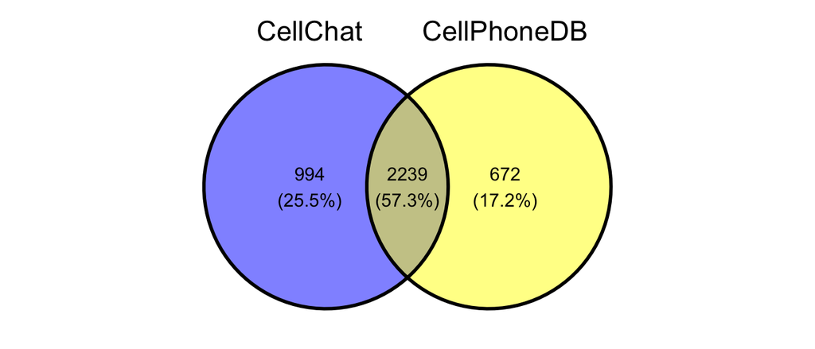

```r
ggvenn::ggvenn(list(CellChat = CC.int$LR, CellPhoneDB = CPDB.int$LR))
```

This concludes the process performed in **Part 1** of the Database harmonisation conducted. In **Part 2**, we outline the customization of the CellChatDB and CellPhoneDB with the proposed changes above. You may refer to **Part 2** [here](https://nigelhojinker.github.io/scpeaker/data-raw/Database_harmonisation_part2.html).